# Figures for dsRNA Survey Paper

Angela Crabtree

29 March, 2022

## Results: Part 1

#### **Prevalence of killer yeasts**

### *Figure 1B*

This figure contains the killing patterns of four S. cerevisiae strains we’ve identified as being “canonical”: BJH001 (K1 toxin), NCYC1001 (K2 toxin), MS300c (K28 toxin), and DSM 70459 (Klus toxin).

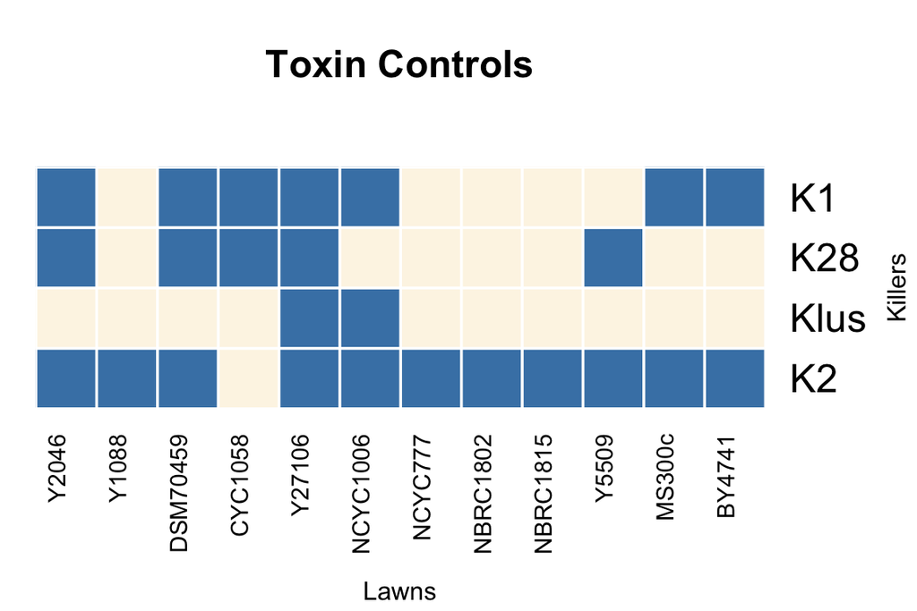

### *Figure 1D*

This figure contains the killing patterns of all *S. cerevisiae* strains we screened in the collections which killed at least one lawn that was not Y2046 (because that lawn is hypersusceptible) or ATCC2001 (a lawn we screened but did not include since is not S. cerevisiae).

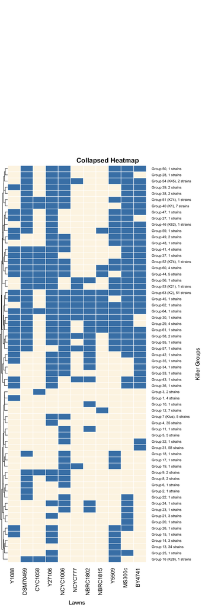

### *Table 1*

```
## [1] "Names of included collections:"
```

```
## [1] "Dudley"   "NGS"      "FGSC"     "Liti1000"
```

```
## [1] "Number of qualified strains: 340"
```

Table 1. The prevalence of dsRNAs in killer and non-killer yeasts in S. cerevisiae

|  | Killer yeast | Non-killer yeast | Total |
| --- | --- | --- | --- |
| No dsRNAs | 109 | 62 | 171 |
| dsRNAs | 130 | 39 | 169 |
| Totivirus only | 39 | 17 | 56 |
| Totivirus and satellite(s) | 89 | 9 | 98 |
| Satellites only | 2 | 13 | 15 |

## Results: Part 2

#### **Identification of unknown toxins**

### *Table 2*

The table shows a numerical comparison between the de novo assembled sequences from NGS with those of the canonical reference sequences.

Table 2. Identification of dsRNA elements from NGS assembly

S. cerevisiae

Toxin type

Identity (nt)

Coverage

Rt-PCR confirmed

YJM1077

K1

>99%

97%

YJM1287

K1

>99%

91%

YJM1307

K1

>99%

90%

YJM1077

K1

98%

97%

yes

YJM1482

K1

99%

>99%

yes

YJM1490

K1

98%

97%

YJM1621

K1

99%

98%

yes

YJM1619

K28

92%

97%

yes

YJM145

Klus

>99%

94%

### *Figure 3*

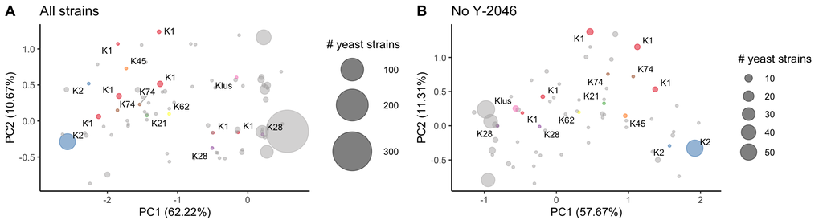

## Results: Part 2

#### **Genome-encoded toxins**

### *Table 3*

This table summarizes the prevalence of KHR and KHS in relation to killing phenotype.

```
## [1] "Names of included collections:"
```

```
## [1] "FGSC"     "Liti1000"
```

```
## [1] "Number of qualified strains: 1084"
```

Table 3. The prevalence of KHR1 and KHS1 in S. cerevisiae

|  | +KHR1 | +KHS1 | -KHR1 | -KHS1 |
| --- | --- | --- | --- | --- |
| Killer yeast | 372 | 453 | 160 | 79 |
| Killer yeast (Y-2046 only) | 225 | 299 | 95 | 21 |
| Non-killer yeast | 387 | 191 | 165 | 361 |

### *Table 4*

This table summarizes the prevalence of KHR and KHS in relation to killing satellite dsRNA presence.

```
## [1] "Number of qualified strains: 175"
```

|  | +KHR1 | +KHS1 | -KHR1 | -KHS1 |
| --- | --- | --- | --- | --- |
| Killer yeast |  |  |  |  |
| +satellite | 42 | 47 | 17 | 12 |
| -satellite | 61 | 75 | 24 | 10 |
| Non-killer yeast |  |  |  |  |
| +satellite | 0 | 0 | 1 | 1 |
| -satellite | 26 | 13 | 4 | 17 |